# Machine Learning Class Project

John R Sullivan

November 11, 2017

# Executive Summary

This assignment was focused on using workout related data to develop a predictive model. The goal was to use provided data from a large dataset (18K+ observations) to predict how effectively individuals were executing prescribed exercises.

There were 5 possible outcomes varying from a very effective exercise execution to several ineffective ones (A-E, respectively). The original training and test files were transformed from 160 to 56 fields by removing primarily blank fields and variables that were logically duplicated in the data.

Principal component analysis (PCA) was then applied, further reducing the number of acting variables. A classification tree model with cross validation was trained subsequently, yielding a prediction on the training data set approaching 66.5% overall accuracy.

The resultant tree model was applied to the 20 observation test data after a PCA transformation based on the training data. The predicted outcomes on the test data were tabled for submission to fulfill the test prediction component of the class exercise.

```
## complete(): tidyr, RCurl
## lift():     purrr, caret
```

# Histogram of exercise effectiveness categories

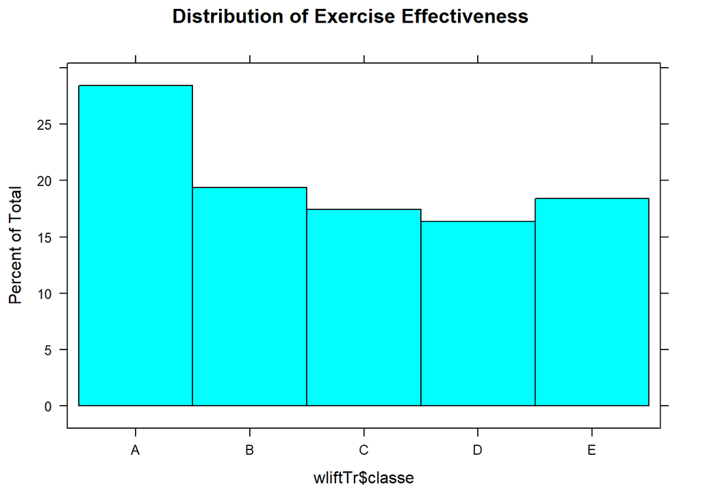

# Process Description

Split Training dataset randomly by classe into training (70% of data)/ verification (30% of data) sets.

Training 70% file (13,737 observations): - Filtered out predictors populated less than 50% of the time in data. This moved the file from 160 to 60 predictors. - Eliminated identification attributes (user_name, row_number) and raw timestamp variables, since they redundant or not relevant to exercise data, reducing columns to 56 - Used caret preprocess features to scale, center remaining data. - Applied caret based Principal Component Analysis (PCA) to consolidate remaining variables. This reduced acting predictors to 25 Principal Components. - Due to shear size of 70% training file (13K+ observations)and number of possible outcomes, applied a classification tree model (rpart) against Principal Components to predict training set outcomes. Incorporated 20/10 cross-validation into the control parameters for the tree calculations. Post prediction Confusion Matrix showed 66.5% overall accuracy of predictions.

```
## Confusion Matrix and Statistics
##
##           Reference
## Prediction    A    B    C    D    E
##          A 3259  139  459   49    0
##          B  648 1065  726  219    0
##          C  113  366 1792   95   30
##          D   17  272  315 1077  571
##          E   29   45   72  442 1937
##
## Overall Statistics
##
##                Accuracy : 0.6646
##                  95% CI : (0.6567, 0.6725)
##     No Information Rate : 0.296
##     P-Value [Acc > NIR] : < 2.2e-16
##
##                   Kappa : 0.5755
##  Mcnemar's Test P-Value : < 2.2e-16
##
## Statistics by Class:
##
##                      Class: A Class: B Class: C Class: D Class: E
## Sensitivity            0.8015  0.56439   0.5327   0.5723   0.7632
## Specificity            0.9331  0.86557   0.9418   0.9009   0.9475
## Pos Pred Value         0.8344  0.40068   0.7479   0.4782   0.7671
## Neg Pred Value         0.9179  0.92581   0.8614   0.9299   0.9464
## Prevalence             0.2960  0.13737   0.2449   0.1370   0.1848
## Detection Rate         0.2372  0.07753   0.1305   0.0784   0.1410
## Detection Prevalence   0.2843  0.19349   0.1744   0.1639   0.1838
## Balanced Accuracy      0.8673  0.71498   0.7372   0.7366   0.8553
```

# Process Description (continued)

Verification 30% file (5885 observations): - Preprocessed file identically to 70% training file - Used 70% Training set PCA based rpart model with cross-validation to predict verification file outcomes - Confusion matrix approached 66.4% overall predictive accuracy

```
## Confusion Matrix and Statistics
##
##           Reference
## Prediction    A    B    C    D    E
##          A 1403   61  196   14    0
##          B  302  445  306   86    0
##          C   56  181  732   41   16
##          D    3  101  141  489  230
##          E   18   15   32  180  837
##
## Overall Statistics
##
##                Accuracy : 0.6637
##                  95% CI : (0.6515, 0.6758)
##     No Information Rate : 0.3028
##     P-Value [Acc > NIR] : < 2.2e-16
##
##                   Kappa : 0.574
##  Mcnemar's Test P-Value : < 2.2e-16
##
## Statistics by Class:
##
##                      Class: A Class: B Class: C Class: D Class: E
## Sensitivity            0.7873  0.55417   0.5203  0.60370   0.7729
## Specificity            0.9340  0.86344   0.9343  0.90640   0.9490
## Pos Pred Value         0.8381  0.39069   0.7135  0.50726   0.7736
## Neg Pred Value         0.9100  0.92457   0.8611  0.93477   0.9488
## Prevalence             0.3028  0.13645   0.2391  0.13764   0.1840
## Detection Rate         0.2384  0.07562   0.1244  0.08309   0.1422
## Detection Prevalence   0.2845  0.19354   0.1743  0.16381   0.1839
## Balanced Accuracy      0.8606  0.70881   0.7273  0.75505   0.8609
```

# Process Description (continued)

Test file Prediction (20 observations): - Preprocessed test file identically to 70% training file - Used 70% Training set PCA based rpart model with cross-validation to predict test file outcomes - Since actual outcomes are not available, represented each of 20 predictions in a table and summary totals

```
##     TestPred
##      A B C D E
##   1  0 0 1 0 0
##   2  0 0 1 0 0
##   3  0 0 1 0 0
##   4  1 0 0 0 0
##   5  1 0 0 0 0
##   6  0 0 0 0 1
##   7  0 0 0 1 0
##   8  0 0 1 0 0
##   9  1 0 0 0 0
##   10 1 0 0 0 0
##   11 1 0 0 0 0
##   12 0 0 1 0 0
##   13 0 1 0 0 0
##   14 1 0 0 0 0
##   15 0 0 0 0 1
##   16 0 0 0 0 1
##   17 1 0 0 0 0
##   18 0 1 0 0 0
##   19 0 0 1 0 0
##   20 0 1 0 0 0
```

```
## A B C D E
## 7 3 6 1 3
```

# Conclusions